# 1 Data

For this case study we will be using [Google’s data on COVID-19 Community Mobility](https://www.google.com/covid19/mobility/index.html?hl=en). You can access the [full details](https://www.google.com/covid19/mobility/data_documentation.html?hl=en) for this data as well. In this tutorial we will be working with data from the United States only.

```r
library(tidyverse)
mobility_data <- read_csv("data/2021_US_Region_Mobility_Report.csv")
```

We need to do some data wrangling, namely we need to pivot the data so that we have the place categories as a variable separate from percent change from baseline. Let’s also remove "_percent_change_from_baseline" from our place categories.

```r
mobility_data_tidy <- mobility_data %>%
  pivot_longer(cols = retail_and_recreation_percent_change_from_baseline:residential_percent_change_from_baseline,
               names_to = "place",
               values_to = "percent_change_from_baseline") %>%
  mutate(place = gsub("_percent_change_from_baseline", "", place))
```

Feel free to explore the other variables in this data set, to understand the data better.

# 2 Model and Visualize the effect of State and Place on Mobility

We will run our linear regression with `percent_change_from_baseline` as the response variable and `sub_region_1` and `place` as predictors (one could image that there’s interaction between these two variables, but we won’t be checking for interaction in this tutorial – you’re of course encouraged to do so).

```r
model <- lm(percent_change_from_baseline ~ sub_region_1 + place,
            data = mobility_data_tidy)
```

We can of course run `summary(model)` to get all coefficients, with the reference as the default for treatment contrasts (i.e., the first level in alphabetical order as the reference). That’s not very useful since it’s hard to read it. We will visualize the effects instead. We can however run `Anova()` (from the `car` library) on our model to get the significance for the entire factor group, in case you need to report that.

```r
library(car)
Anova(model)
```

```
## Anova Table (Type II tests)
##
## Response: percent_change_from_baseline
##                  Sum Sq      Df  F value    Pr(>F)
## sub_region_1   62405065      50   2223.7 < 2.2e-16 ***
## place         552705800       5 196951.1 < 2.2e-16 ***
## Residuals    1630202130 2904530
## ---
## Signif. codes:  0 '***' 0.001 '**' 0.01 '*' 0.05 '.' 0.1 ' ' 1
```

Let’s get our effects for both categorical variables (separately because we didn’t run the interaction) using the `effect()` function from the `effects` library. We will also rename `sub_region_1` to `state` so it’s easier to visualize these results later.

```r
library(effects)
us_state_effect_on_mobility <- effect("sub_region_1", model) %>%
  data.frame() %>%
  rename(state = sub_region_1)

place_effect_on_mobility <- effect("place", model) %>%
  data.frame()
```

## 2.1 Visualize the effect of place on mobility

We will create our error bar plot (which we’ve done many times before). We will use `labs()` to provide more information about what is being visualized.

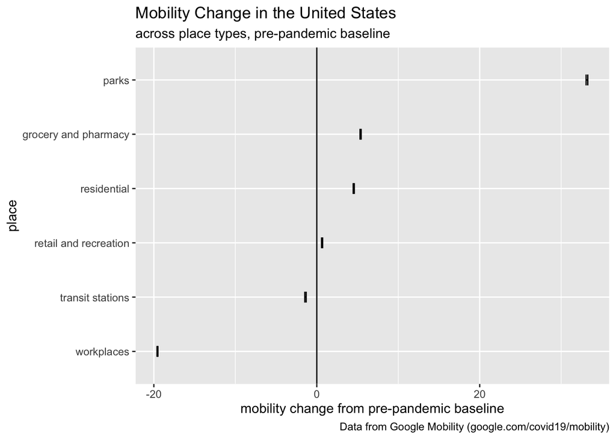

```r
place_effect_on_mobility %>%
  mutate(place = gsub("_", " ", place)) %>%
  ggplot(aes(y = reorder(place, fit),
             x = fit,
             xmin = lower,
             xmax = upper)) +
  geom_errorbar(width = .2) +
  geom_vline(xintercept = 0) +
  labs(title = "Mobility Change in the United States",
       subtitle = "across place types, pre-pandemic baseline",
       x = "mobility change from pre-pandemic baseline",
       y = "place",
       caption = "Data from Google Mobility (google.com/covid19/mobility)")
```

> What are the strengths and weak points of the plot above in terms of communicating the results of our model?

## 2.2 Visualize the effect of state on mobility

We will use a library that is specific to US maps in this tutorial (you can use `geom_map()` too). Remember that we renamed the state column to be called `state` (without a `state` column this won’t work).

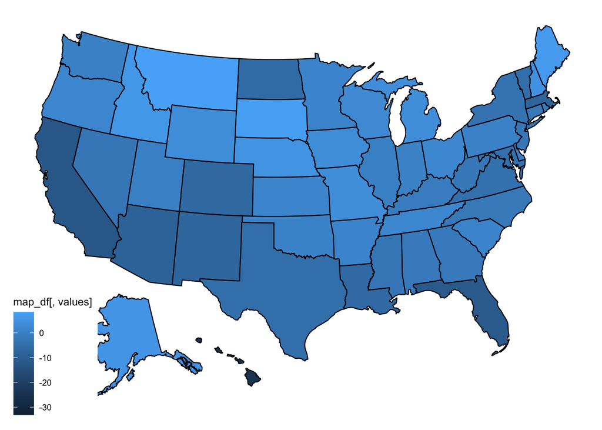

```r
library(usmap)
plot_usmap(data = us_state_effect_on_mobility,
           values = "fit")
```

We need to make some changes to make this plot easier to read.

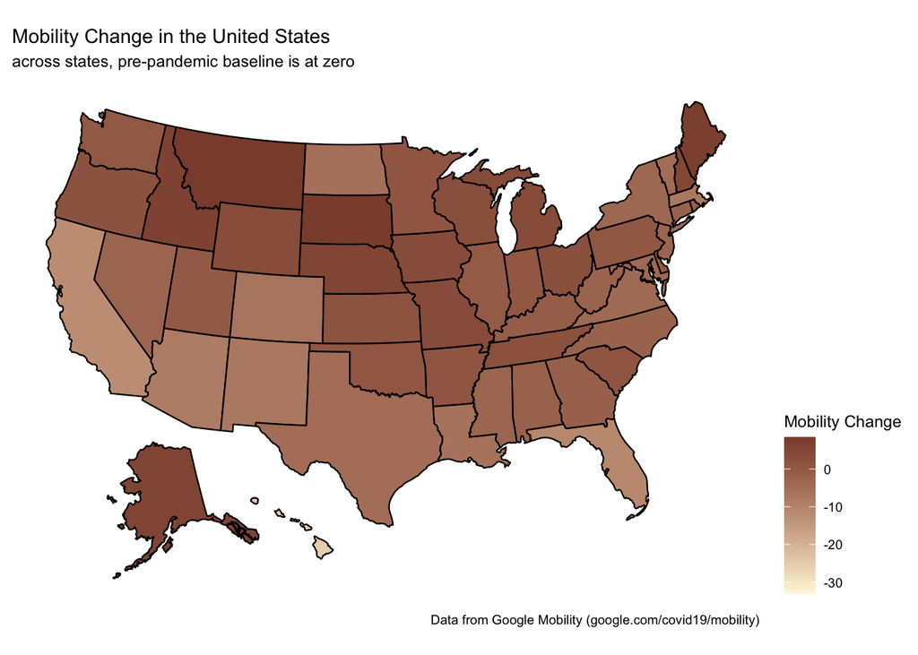

```r
plot_usmap(data = us_state_effect_on_mobility,
           values = "fit")  +
  theme(legend.position = "right") +
  scale_fill_continuous(name = "Mobility Change",
                        low = "cornsilk",
                        high = "salmon4") +
  labs(title = "Mobility Change in the United States",
       subtitle = "across states, pre-pandemic baseline is at zero",
       caption = "Data from Google Mobility (google.com/covid19/mobility)")
```

Let’s compare the map visualization with the error bar visualization:

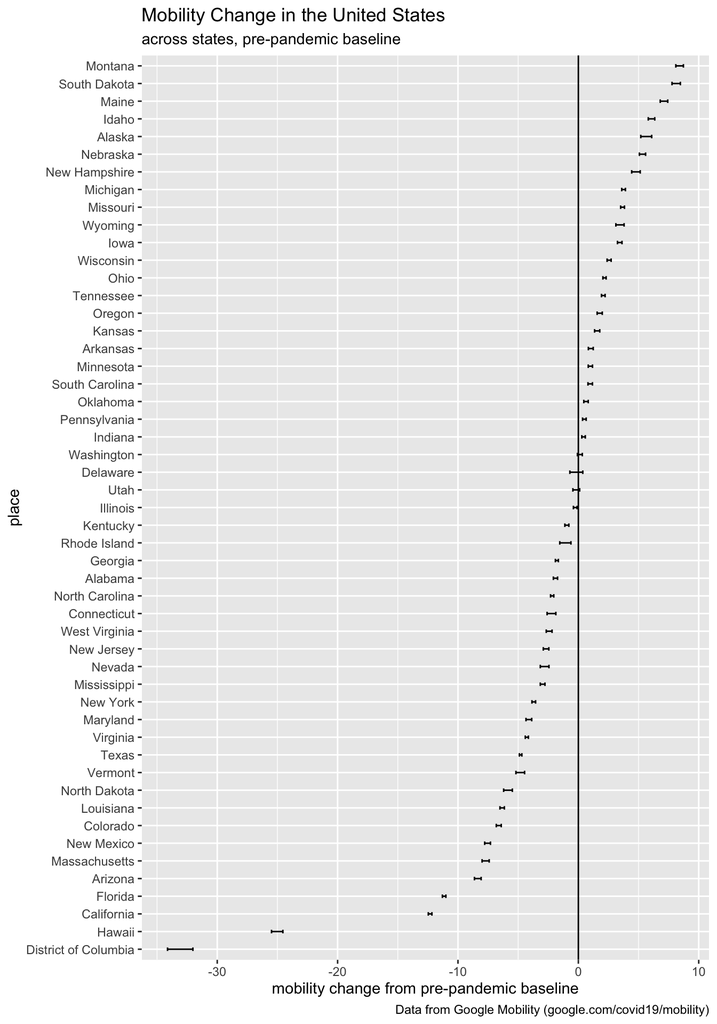

```r
us_state_effect_on_mobility %>%
  ggplot(aes(y = reorder(state, fit),
             x = fit,
             xmin = lower,
             xmax = upper)) +
  geom_errorbar(width = .2) +
  geom_vline(xintercept = 0) +
  labs(title = "Mobility Change in the United States",
       subtitle = "across states, pre-pandemic baseline",
       x = "mobility change from pre-pandemic baseline",
       y = "place",
       caption = "Data from Google Mobility (google.com/covid19/mobility)")
```

> Which of these two plots that display mobility change would you use? Why?